# WECA Data Platform: Analyst Guide

Accessing shared datasets via pins and DuckLake

Author

West of England Combined Authority

Published

February 26, 2026

[figure not shown]

# Introduction

WECA’s shared data platform provides **18 curated datasets** covering local authority lookups, greenhouse gas emissions, energy performance certificates, deprivation indices, postcode centroids, tenure, and spatial boundaries. All data is stored on Amazon S3 and accessible through two complementary routes:

- **Pins (R or Python):** Read datasets directly into data frames. Best for quick exploratory analysis, filtering, and visualisation.
- **DuckLake (SQL via DuckDB CLI):** Query datasets with SQL, join across tables, use pre-built WECA-filtered views, and browse the data catalogue. Best for complex queries and when you need to work across multiple tables.

Both routes read from the same underlying data. Choose whichever fits your workflow – or use both.

**TipThe 10-minute promise**

If you follow the Prerequisites section below, you will be able to read your first dataset within 10 minutes.

This guide covers everything you need: package installation, AWS credential setup, reading data via pins, querying the DuckLake catalogue with SQL, working with spatial data, and troubleshooting common issues. Python equivalents are provided in Appendix A.

# Prerequisites and Setup

Before accessing data, you need three things: R packages, the DuckDB command-line tool (for SQL access), and AWS credentials. This section walks through each.

## R Packages

Install the core packages. This guide assumes you already have the tidyverse installed.

```r
install.packages(c("pins", "arrow", "sf", "duckdb", "DBI"))
```

| Package | Purpose |
| --- | --- |
| `pins` | Connect to the S3 board, list/read/download datasets |
| `arrow` | Read parquet files (required for large and spatial datasets) |
| `sf` | Handle spatial data (GeoParquet to sf objects) |
| `duckdb` | DuckDB database driver for R (used for local queries) |
| `DBI` | Database interface (works with duckdb) |

## DuckDB Installation

The DuckDB command-line interface (CLI) is required for querying the DuckLake catalogue. The R `duckdb` package (v1.4.4) does not include the `ducklake` extension, so SQL queries against the catalogue must be run through the CLI.

1. Download the DuckDB CLI from https://duckdb.org/docs/installation/.
2. Place the `duckdb` executable somewhere on your PATH.
3. Verify installation:

```bash
duckdb --version
```

```
v1.4.1 (Groundhog Day)
```

**Note**

The DuckDB CLI is only needed for DuckLake SQL queries (Section 5). For reading data via pins, you only need the R packages above.

## AWS Credentials

You need AWS credentials to access the shared S3 bucket (`stevecrawshaw-bucket`). Request an access key ID and secret access key from the data owner (distributed via Keeper).

### Step 1: Create the credentials file

Create the file at:

- **Windows:** `C:\Users\USERNAME\.aws\credentials`
- **Linux/Mac:** `~/.aws/credentials`

If the `.aws` directory does not exist, create it first. Paste the following content, replacing the placeholders with your actual keys:

```
[default]
aws_access_key_id = <YOUR_ACCESS_KEY_ID>
aws_secret_access_key = <YOUR_SECRET_ACCESS_KEY>
```

### Step 2: Create the config file

Create the file at:

- **Windows:** `C:\Users\USERNAME\.aws\config`
- **Linux/Mac:** `~/.aws/config`

Paste the following content:

```
[default]
region = eu-west-2
output = json
```

**WarningRegion must be eu-west-2**

The S3 bucket is in the `eu-west-2` (London) region. Using any other region will cause “Access Denied” errors or 301 redirects. Always set `region = eu-west-2`.

### Step 3: Verify access

Pick whichever tool you use day-to-day. A successful result from any one method confirms your credentials are working.

**R (pins):**

```r
library(pins)
board <- board_s3(bucket = "stevecrawshaw-bucket",
                  prefix = "pins/",
                   region = "eu-west-2")
pin_list(board)
```

**DuckDB CLI:**

```sql
INSTALL aws; LOAD aws;
CREATE OR REPLACE SECRET (
    TYPE s3, PROVIDER credential_chain,
    CHAIN config, REGION 'eu-west-2'
);
SELECT * FROM glob('s3://stevecrawshaw-bucket/*');
```

**AWS CLI (optional):**

```bash
aws s3 ls s3://stevecrawshaw-bucket/
```

**TipTroubleshooting credentials**

If you get “Access Denied” or “No credentials” errors, see the Troubleshooting section. Common causes: wrong region, missing profile name `[default]`, or a `.txt` extension accidentally added by your text editor.

# Available Datasets

The platform provides 18 base tables and 12 pre-built views. The table below is a quick reference; for full column-level details, query the `datasets_catalogue` and `columns_catalogue` programmatically (see Querying the Data Catalogue).

## Base Tables

[output not shown]

## Views (WECA-filtered)

The catalogue includes 12 views. Four are source views that reshape or join data; the remaining eight pre-filter data to the four WECA local authorities (Bath and North East Somerset, Bristol, North Somerset, South Gloucestershire). Views have names ending in `_weca_vw`, `_vw`, or `_ods_vw`.

| Name | Description |
| --- | --- |
| `ca_la_lookup_inc_ns_vw` | CA/LA lookup including North Somerset |
| `weca_lep_la_vw` | WECA LEP local authorities (4 rows) |
| `ca_la_ghg_emissions_sub_sector_ods_vw` | GHG emissions joined with CA/LA lookup |
| `epc_domestic_vw` | Domestic EPC with derived fields (construction year, tenure) |
| `la_ghg_emissions_weca_vw` | GHG emissions filtered to WECA LAs |
| `la_ghg_emissions_wide_weca_vw` | GHG emissions (wide) filtered to WECA LAs |
| `raw_domestic_epc_weca_vw` | Domestic EPC filtered to WECA LAs |
| `raw_non_domestic_epc_weca_vw` | Non-domestic EPC filtered to WECA LAs |
| `boundary_lookup_weca_vw` | Boundary lookup filtered to WECA LAs |
| `postcode_centroids_weca_vw` | Postcode centroids filtered to WECA LAs |
| `iod2025_weca_vw` | Index of Deprivation 2025 filtered to WECA LAs |
| `ca_la_lookup_weca_vw` | CA/LA lookup filtered to WECA LAs |

**Note**

Row counts are approximate. For exact current counts, query `datasets_catalogue` in DuckLake (see Section 5.5).

# Accessing Data via Pins

The `pins` package is the primary way to read data from the platform into R. All datasets are stored as versioned parquet files on S3.

## Creating a Board

Connect to the S3 board. You only need to do this once per session.

```r
library(pins)

board <- board_s3(
  bucket = "stevecrawshaw-bucket",
  prefix = "pins/",
  region = "eu-west-2",
  versioned = TRUE
)
```

The `versioned = TRUE` parameter means you can access previous versions of datasets if needed.

## Listing Datasets

See all available datasets on the board:

```r
pin_list(board)
```

```
 [1] "bdline_ua_lep_diss_tbl"
 [2] "bdline_ua_lep_tbl"
 [3] "bdline_ua_weca_diss_tbl"
 [4] "bdline_ward_lep_tbl"
 [5] "boundary_lookup_tbl"
 [6] "ca_boundaries_bgc_tbl"
 [7] "ca_la_lookup_tbl"
 [8] "codepoint_open_lep_tbl"
 [9] "columns_catalogue"
[10] "datasets_catalogue"
[11] "eng_lsoa_imd_tbl"
[12] "iod2025_tbl"
[13] "la_ghg_emissions_tbl"
[14] "la_ghg_emissions_wide_tbl"
[15] "lsoa_2021_lep_tbl"
[16] "open_uprn_lep_tbl"
[17] "postcode_centroids_tbl"
[18] "raw_domestic_epc_certificates_tbl"
[19] "raw_non_domestic_epc_certificates_tbl"
[20] "uk_lsoa_tenure_tbl"
```

## Reading a Dataset

Read a dataset directly into an R data frame with `pin_read()`. Start with `ca_la_lookup_tbl` – it is small (106 rows) and loads instantly.

```r
df <- pin_read(board, "ca_la_lookup_tbl")
head(df)
```

```
# A data frame: 6 × 5
  LAD25CD   LAD25NM    CAUTH25CD CAUTH25NM          ObjectId
* <chr>     <chr>      <chr>     <chr>                 <dbl>
1 E08000001 Bolton     E47000001 Greater Manchester        1
2 E08000002 Bury       E47000001 Greater Manchester        2
3 E08000003 Manchester E47000001 Greater Manchester        3
4 E08000004 Oldham     E47000001 Greater Manchester        4
5 E08000005 Rochdale   E47000001 Greater Manchester        5
6 E08000006 Salford    E47000001 Greater Manchester        6
```

```r
str(df)
```

```
Classes 'tbl' and 'data.frame': 106 obs. of  5 variables:
 $ LAD25CD  : chr  "E08000001" "E08000002" "E08000003" "E08000004" ...
 $ LAD25NM  : chr  "Bolton" "Bury" "Manchester" "Oldham" ...
 $ CAUTH25CD: chr  "E47000001" "E47000001" "E47000001" "E47000001" ...
 $ CAUTH25NM: chr  "Greater Manchester" "Greater Manchester" "Greater Manchester" "Greater Manchester" ...
 $ ObjectId : num  1 2 3 4 5 6 7 8 9 10 ...
```

## Accessing Metadata

Every dataset carries metadata including a description and column-level documentation:

```r
meta <- pin_meta(board, "ca_la_lookup_tbl")
meta$title
```

```
[1] "Combined authority local authority boundaries"
```

```r
meta$user$columns
```

```
$LAD25CD
[1] "Local authority district code 2025"

$LAD25NM
[1] "Local authority district name 2025"

$CAUTH25CD
[1] "Combined authority code 2025"

$CAUTH25NM
[1] "Combined authority name 2025"

$ObjectId
[1] "Objectid"
```

Column descriptions come from the data catalogue and are embedded in each pin’s metadata. Use `meta$user$column_types` to see the data types.

## Large Datasets

The `raw_domestic_epc_certificates_tbl` dataset contains approximately 19 million rows and is stored as a multi-file pin (multiple parquet files). For this table, `pin_read()` may be slow or fail. Use `arrow::open_dataset()` instead:

```r
library(arrow)

# Download the parquet files
paths <- pin_download(board, "raw_domestic_epc_certificates_tbl")

# Open as an Arrow dataset (lazy -- does not load into memory)
ds <- open_dataset(paths)

# Query efficiently with dplyr
library(dplyr)
bristol_epcs <- ds |>
  filter(local_authority == "Bristol, City of") |>
  select(address1, current_energy_rating, potential_energy_rating) |>
  collect()
```

**Tip**

For any dataset, you can use `pin_download()` followed by `arrow::read_parquet()` if you prefer working with Arrow tables directly. This is also the required approach for spatial datasets (see Section 6).

# Querying the DuckLake Catalogue

DuckLake provides SQL access to the same datasets. This is useful when you need to join tables, run aggregate queries, use pre-built WECA views, or browse the data catalogue. All DuckLake SQL runs through the DuckDB CLI (not the R duckdb package).

## Installing Extensions

Open the DuckDB CLI and install the required extensions. This only needs to be done once – extensions are cached locally.

```sql
INSTALL ducklake;
LOAD ducklake;

INSTALL httpfs;
LOAD httpfs;

INSTALL aws;
LOAD aws;
```

For spatial queries, also install:

```sql
INSTALL spatial;
LOAD spatial;
```

## Attaching the Catalogue

Each time you open a DuckDB CLI session, you need to create an S3 credential and attach the catalogue.

```sql
-- Create S3 credential (uses your ~/.aws/credentials file)
CREATE SECRET (TYPE s3, REGION 'eu-west-2', PROVIDER credential_chain);

-- Attach the DuckLake catalogue
ATTACH 'ducklake:data/mca_env.ducklake' AS lake
  (READ_ONLY, DATA_PATH 's3://stevecrawshaw-bucket/ducklake/data/');
```

**ImportantYou need the .ducklake file locally**

The file `data/mca_env.ducklake` is a small metadata file that must be on your local machine. Clone the repository to get it:

```bash
git clone <repo-url>
cd ducklake
```

The `.ducklake` file is only metadata (a few KB). The actual data lives on S3 and is fetched transparently when you run queries.

To see all available tables and views:

```sql
USE lake;
SHOW TABLES;
```

## Basic SQL Queries

**Select all rows from a small table:**

```sql
SELECT * FROM lake.ca_la_lookup_tbl LIMIT 5;
```

**Filter with WHERE:**

```sql
SELECT LAD25NM, population
FROM lake.ca_la_lookup_tbl
WHERE CAUTH25NM = 'West of England'
ORDER BY population DESC;
```

**Aggregate with GROUP BY:**

```sql
SELECT territorial_emissions_sector,
       ROUND(SUM(territorial_emissions_kt_co2e), 1) AS total_kt
FROM lake.la_ghg_emissions_tbl
WHERE local_authority_name IN ('Bristol, City of', 'Bath and North East Somerset',
                                'North Somerset', 'South Gloucestershire')
  AND year = 2021
GROUP BY territorial_emissions_sector
ORDER BY total_kt DESC;
```

**Join tables:**

```sql
SELECT l.LAD25NM, g.year,
       ROUND(SUM(g.territorial_emissions_kt_co2e), 1) AS total_emissions
FROM lake.la_ghg_emissions_tbl g
JOIN lake.ca_la_lookup_tbl l ON g.local_authority_code = l.LAD25CD
WHERE l.CAUTH25NM = 'West of England'
GROUP BY l.LAD25NM, g.year
ORDER BY g.year DESC, total_emissions DESC
LIMIT 8;
```

## Using Views

WECA-filtered views pre-filter data to the four WECA local authorities, saving you from writing the same WHERE clause repeatedly.

```sql
-- Instead of filtering manually:
SELECT * FROM lake.la_ghg_emissions_tbl
WHERE local_authority_code IN ('E06000022','E06000023','E06000024','E06000025');

-- Use the WECA view directly:
SELECT * FROM lake.la_ghg_emissions_weca_vw;
```

```sql
-- List distinct authorities in a WECA view
SELECT DISTINCT local_authority_code, local_authority_name
FROM lake.la_ghg_emissions_weca_vw;
```

## Querying the Data Catalogue

The catalogue includes two metadata tables that describe every dataset and column programmatically.

**List all datasets with descriptions and row counts:**

```sql
SELECT name, description, type, row_count
FROM lake.datasets_catalogue
ORDER BY type, name;
```

**Explore columns for a specific table:**

```sql
SELECT column_name, data_type, description, example_1
FROM lake.columns_catalogue
WHERE table_name = 'la_ghg_emissions_tbl'
ORDER BY column_name;
```

**Find spatial datasets:**

```sql
SELECT name, geometry_type, crs, row_count
FROM lake.datasets_catalogue
WHERE geometry_type IS NOT NULL;
```

## Time Travel

DuckLake keeps snapshots of your data. You can query a table as it existed at a previous version:

```sql
-- Query the table at version 1
SELECT COUNT(*) FROM lake.ca_la_lookup_tbl AT (VERSION => 1);

-- List available snapshots
SELECT * FROM lake.snapshots() ORDER BY snapshot_id DESC LIMIT 5;
```

Snapshots are retained for 90 days and then automatically cleaned up. Time travel is useful for auditing changes or recovering from accidental modifications.

# Working with Spatial Data

Eight of the 18 datasets contain geometry columns and are stored as GeoParquet files on S3. These cover boundaries (UA, ward, LSOA), postcodes (Codepoint Open), addresses (UPRN), and combined authority areas.

**WarningDo not use sfarrow**

The `sfarrow` package fails on GeoParquet files produced by DuckDB because DuckDB does not write CRS metadata into the GeoParquet `geo` key. Always use the `arrow` + `sf` approach described below.

## Reading GeoParquet Pins

Spatial pins must be read with `pin_download()` followed by `arrow::read_parquet()`, not with `pin_read()`:

```r
# Download the GeoParquet file
pin_path <- pin_download(board, "bdline_ua_lep_tbl")

# Read with arrow
arrow_tbl <- arrow::read_parquet(pin_path, as_data_frame = FALSE)
```

## Converting to sf Objects

Convert the Arrow table to an `sf` object in two steps:

```r
sf_obj <- sf::st_as_sf(as.data.frame(arrow_tbl))
```

The two-step process (`as.data.frame()` then `st_as_sf()`) is needed because `sf` expects a data frame with a geometry column, and Arrow tables need explicit conversion.

```r
sf_obj
```

```
Simple feature collection with 4 features and 3 fields
Geometry type: MULTIPOLYGON
Dimension:     XY
Bounding box:  xmin: 322292.8 ymin: 152770 xmax: 382605.5 ymax: 198319.9
CRS:           NA
                          name      code id                          shape
1 Bath and North East Somerset E06000022  1 MULTIPOLYGON (((376262.8 17...
2              City of Bristol E06000023  2 MULTIPOLYGON (((353416.3 18...
3        South Gloucestershire E06000025  3 MULTIPOLYGON (((364881.8 19...
4               North Somerset E06000024  4 MULTIPOLYGON (((349585 1781...
```

## Setting CRS

Notice that the CRS shows as **NA** above. DuckDB does not embed CRS metadata into GeoParquet files, so you **must** set it explicitly after reading.

```r
sf_obj <- sf::st_set_crs(sf_obj, 27700)
```

Most spatial tables use **EPSG:27700** (British National Grid). The one exception is `ca_boundaries_bgc_tbl`, which uses **EPSG:4326** (WGS84 latitude/longitude).

| Dataset | CRS |
| --- | --- |
| `bdline_ua_lep_diss_tbl` | EPSG:27700 |
| `bdline_ua_lep_tbl` | EPSG:27700 |
| `bdline_ua_weca_diss_tbl` | EPSG:27700 |
| `bdline_ward_lep_tbl` | EPSG:27700 |
| `ca_boundaries_bgc_tbl` | **EPSG:4326** |
| `codepoint_open_lep_tbl` | EPSG:27700 |
| `lsoa_2021_lep_tbl` | EPSG:27700 |
| `open_uprn_lep_tbl` | EPSG:27700 |

You can also check the correct CRS from the pin metadata:

```r
meta <- pin_meta(board, "bdline_ua_lep_tbl")
meta$user$crs
```

```
[1] "EPSG:27700"
```

## Plotting a Quick Map

Once the CRS is set, you can plot directly:

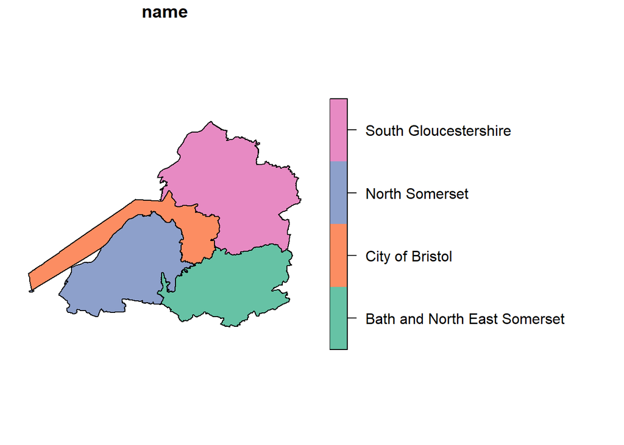

```r
plot(sf_obj["name"])
```

For a more polished map using ggplot2:

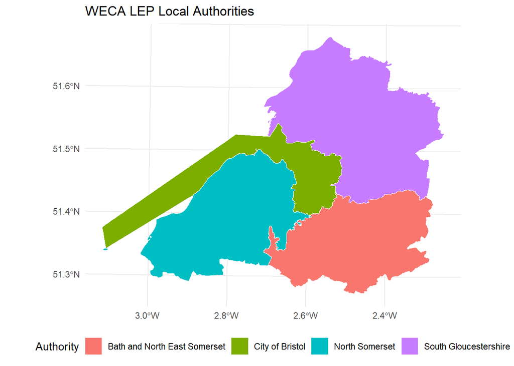

```r
ggplot(sf_obj) +
  geom_sf(aes(fill = name), colour = "white") +
  theme_minimal() +
  labs(title = "WECA LEP Local Authorities",
       fill = "Authority") +
  theme(legend.position = "bottom")
```

# Troubleshooting

## “Access Denied” or region errors

**Symptom:** S3 operations fail with “Access Denied”, 403, or 301 redirect errors.

**Cause:** The region is not set to `eu-west-2`, or credentials are missing/expired.

**Fix:**

1. Check `~/.aws/config` contains `region = eu-west-2`.
2. In DuckDB, always specify `REGION 'eu-west-2'` in the secret definition.
3. Verify your credentials have not expired – contact the data owner for new keys if needed.

## “File not found” when attaching DuckLake

**Symptom:** `ATTACH 'ducklake:data/mca_env.ducklake'` fails with a file-not-found error.

**Cause:** The `.ducklake` catalogue file must be on your local machine. It is not hosted on S3.

**Fix:** Clone the repository and run DuckDB from the project root directory:

```bash
git clone <repo-url>
cd ducklake
duckdb
```

## CRS shows as NA or OGC:CRS84

**Symptom:** After reading a spatial dataset, `sf::st_crs()` returns NA, or geopandas shows `OGC:CRS84`.

**Cause:** DuckDB does not embed CRS metadata into GeoParquet files.

**Fix:** Set the CRS explicitly after reading. Most tables use EPSG:27700; `ca_boundaries_bgc_tbl` uses EPSG:4326. See the CRS table above.

## sfarrow fails on GeoParquet

**Symptom:** `sfarrow::st_read_parquet()` throws an error about missing CRS or `geo` key.

**Cause:** sfarrow requires full GeoParquet metadata including CRS, which DuckDB does not write.

**Fix:** Use `arrow::read_parquet()` followed by `sf::st_as_sf()` instead. Do not use sfarrow with these files.

## Python board_s3 path format

**Symptom:** Python `board_s3()` fails with connection errors or “bucket not found”.

**Cause:** Python `pins` uses a different path format from R.

**Fix:** Use `board_s3("stevecrawshaw-bucket/pins", versioned=True)` – the bucket and prefix are combined in a single string. Do not pass them as separate parameters.

## Python pin_read fails on EPC table

**Symptom:** `board.pin_read("raw_domestic_epc_certificates_tbl")` throws an error in Python.

**Cause:** The EPC table is a multi-file pin (exported in chunks). The Python `pins` library cannot handle multi-file pins with `pin_read`.

**Fix:** Use `pyarrow` directly:

```python
import pyarrow.dataset as ds
paths = board.pin_download("raw_domestic_epc_certificates_tbl")
dataset = ds.dataset(paths, format="parquet")
df = dataset.to_table().to_pandas()
```

## DuckLake extension not available in R

**Symptom:** `dbExecute(con, "INSTALL ducklake")` fails from the R `duckdb` package.

**Cause:** The R `duckdb` package (v1.4.4) does not include the `ducklake` extension.

**Fix:** Use the DuckDB CLI for all DuckLake queries. For data frame access, use `pins` instead – you do not need DuckLake for reading data into R.

# Support and Contact

**NoteUpdate before distributing**

For urgent data access issues, check the Troubleshooting section first.

## Appendix A: Python Equivalents

This appendix provides Python equivalents of the key R examples above. Python is a secondary access path – R is the primary supported language.

## Pins Access

**ImportantPython path format differs from R**

In Python, `board_s3()` takes a single string `"bucket/prefix"` rather than separate `bucket` and `prefix` parameters. Note the absence of a trailing slash.

```python
import os
os.environ.setdefault("AWS_DEFAULT_REGION", "eu-west-2")

from pins import board_s3

# Create board -- note the "bucket/prefix" format (no trailing slash)
board = board_s3("stevecrawshaw-bucket/pins", versioned=True)

# List datasets
board.pin_list()
```

```python
# Read a dataset
df = board.pin_read("ca_la_lookup_tbl")
print(df.head())
```

```python
# Read metadata
meta = board.pin_meta("ca_la_lookup_tbl")
print(meta.title)
print(meta.user["columns"])
```

**Warning**

`pin_read()` fails on multi-file pins (e.g., the EPC table). Use `pyarrow.dataset` as shown in the Troubleshooting section.

## DuckLake Queries

You can run DuckLake SQL from Python using the `duckdb` package:

```python
import duckdb

conn = duckdb.connect()

# Install and load extensions
conn.execute("INSTALL ducklake; LOAD ducklake;")
conn.execute("INSTALL httpfs; LOAD httpfs;")
conn.execute("INSTALL aws; LOAD aws;")

# Create S3 credential
conn.execute("CREATE SECRET (TYPE s3, REGION 'eu-west-2', PROVIDER credential_chain);")

# Attach the DuckLake catalogue
conn.execute("""
    ATTACH 'ducklake:data/mca_env.ducklake' AS lake
    (READ_ONLY, DATA_PATH 's3://stevecrawshaw-bucket/ducklake/data/');
""")

# Query
df = conn.execute("SELECT * FROM lake.ca_la_lookup_tbl LIMIT 5").fetchdf()
print(df)
```

**Note**

Unlike R, the Python `duckdb` package does support the `ducklake` extension. You can run DuckLake queries directly from Python without the CLI.

## Spatial Data with geopandas

```python
import os
os.environ.setdefault("AWS_DEFAULT_REGION", "eu-west-2")

from pins import board_s3
import geopandas as gpd

board = board_s3("stevecrawshaw-bucket/pins", versioned=True)

# Download and read GeoParquet
path = board.pin_download("bdline_ua_lep_tbl")
gdf = gpd.read_parquet(path[0])

# CRS may show as OGC:CRS84 -- override to the correct CRS
gdf = gdf.set_crs("EPSG:27700", allow_override=True)

# Quick plot
gdf.plot(column="name", legend=True)
```

**Warning**

geopandas may report the CRS as `OGC:CRS84` when GeoParquet lacks CRS metadata. Always use `set_crs()` with `allow_override=True` to set the correct CRS.

## Appendix B: SQL Quick Reference

A brief SQL primer for analysts who are familiar with R but new to SQL. All examples use DuckLake tables.

**SELECT – choose columns:**

```sql
SELECT LAD25NM, population
FROM lake.ca_la_lookup_tbl;
```

R equivalent: `df |> select(LAD25NM, population)`

**WHERE – filter rows:**

```sql
SELECT LAD25NM, population
FROM lake.ca_la_lookup_tbl
WHERE CAUTH25NM = 'West of England';
```

R equivalent: `df |> filter(CAUTH25NM == "West of England")`

**ORDER BY – sort results:**

```sql
SELECT LAD25NM, population
FROM lake.ca_la_lookup_tbl
ORDER BY population DESC;
```

R equivalent: `df |> arrange(desc(population))`

**LIMIT – return a fixed number of rows:**

```sql
SELECT * FROM lake.la_ghg_emissions_tbl LIMIT 10;
```

R equivalent: `df |> head(10)` or `df |> slice_head(n = 10)`

**GROUP BY – aggregate:**

```sql
SELECT CAUTH25NM, COUNT(*) AS n_las, SUM(population) AS total_pop
FROM lake.ca_la_lookup_tbl
GROUP BY CAUTH25NM
ORDER BY total_pop DESC;
```

R equivalent: `df |> group_by(CAUTH25NM) |> summarise(n_las = n(), total_pop = sum(population))`

**JOIN – combine tables:**

```sql
SELECT l.LAD25NM, g.year, g.territorial_emissions_kt_co2e
FROM lake.la_ghg_emissions_tbl g
JOIN lake.ca_la_lookup_tbl l
  ON g.local_authority_code = l.LAD25CD
WHERE l.CAUTH25NM = 'West of England'
  AND g.year = 2021;
```

R equivalent: `left_join(ghg, lookup, by = c("local_authority_code" = "LAD25CD"))`

**Common aggregate functions:**

| SQL | R equivalent | Description |
| --- | --- | --- |
| `COUNT(*)` | `n()` | Number of rows |
| `SUM(col)` | `sum(col)` | Total |
| `AVG(col)` | `mean(col)` | Average |
| `MIN(col)` | `min(col)` | Minimum |
| `MAX(col)` | `max(col)` | Maximum |
| `ROUND(col, 2)` | `round(col, 2)` | Round to N decimals |